# Exam 3

James

4/11/2020

### This is how I did exam 3

#### for Data Analysis

First, load the packages and the data:

```r
library(tidyverse)
library(GGally)
library(modelr)
library(sjPlot)
library(dplyr)
data("mtcars")
```

Next,look at the data:

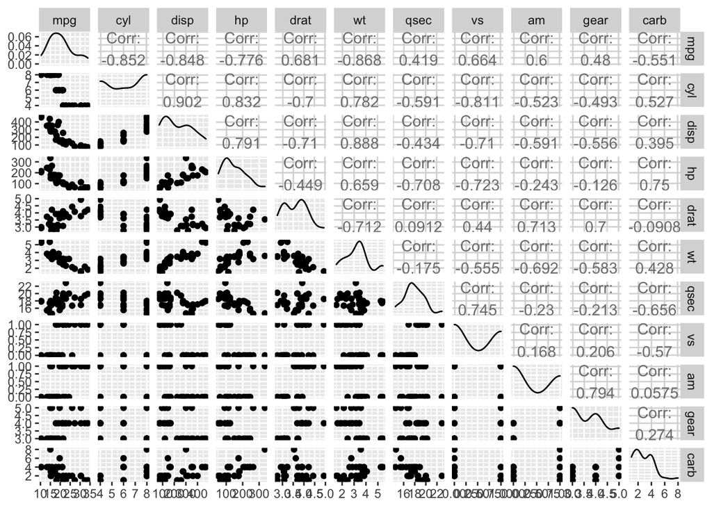

```r
ggpairs(mtcars)
```

This looks like a lot of data. We are trying to find possible relationships between **mpg** and the other variables. We use the *sort* function to show the correlation values between the given variables:

```r
sort(cor(mtcars)[1,])
```

```
##         wt        cyl       disp         hp       carb       qsec       gear
## -0.8676594 -0.8521620 -0.8475514 -0.7761684 -0.5509251  0.4186840  0.4802848
##         am         vs       drat        mpg
##  0.5998324  0.6640389  0.6811719  1.0000000
```

We can see that **wt** and **cyl** are signicicant (although they are negative, meaning that when **mpg** goes up, both **wt** and **cyl** go down).

##### What does it mean when we say they are signicifant?

The correlation coefficient r measures the strength and direction of a linear relationship between two variables on a scatterplot. The value of r is always between +1 and -1.

- 1 = a perfectly linear, positive relationship
- 0 = no relationship
- -1 = a perfectly linear, negative relationship

#### Now, get the p-value

The cor.test function returns several values, including the p-value from the test of significance.

- p < 0.05 = the correlation is likely significant
- p > 0.05 indicates it is not

```r
cortest <- cor.test(mtcars$mpg, as.numeric(mtcars$wt))
cortest$p.value; cortest$conf.int
```

```
## [1] 1.293959e-10
```

```
## [1] -0.9338264 -0.7440872
## attr(,"conf.level")
## [1] 0.95
```

From the above result it is seen that the p-value is 1.293 × 10^-10. This is much less than 0.05; hence, significant corelation.

We will also run this test for the **cyl** variable:

```r
cortest <- cor.test(mtcars$mpg, as.numeric(mtcars$cyl))
cortest$p.value; cortest$conf.int
```

```
## [1] 6.112687e-10
```

```
## [1] -0.9257694 -0.7163171
## attr(,"conf.level")
## [1] 0.95
```

Again, the small p-value indicates that it is significant.

So, we will be using the column **mpg** as our dependent variable (y-axis) and build a quick plot showing its relationship to **wt** and **cyl**:

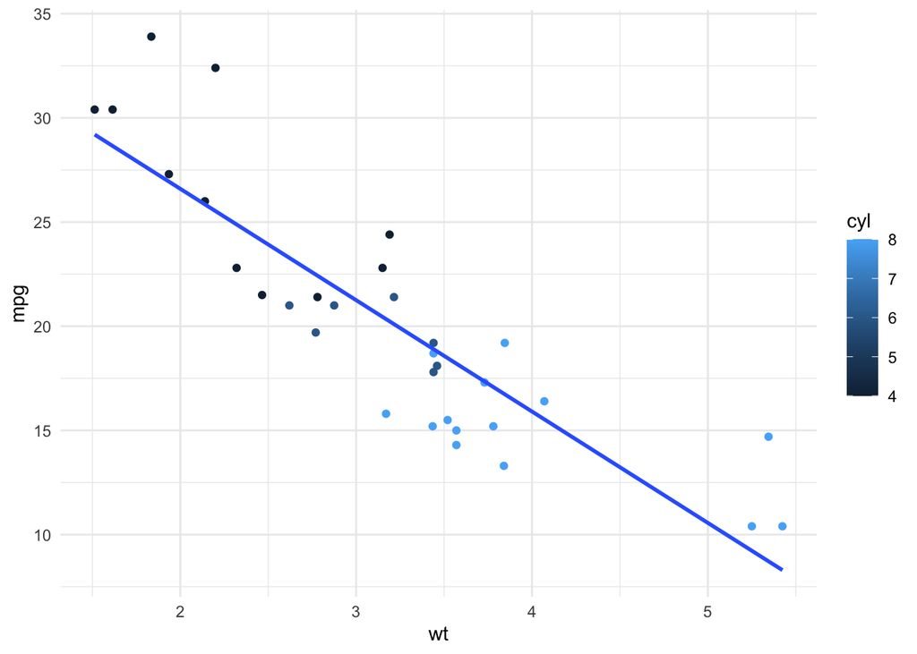

```r
ggplot(mtcars, aes(x=wt,y=mpg,color=cyl)) +
  geom_point() +
  geom_smooth(method="lm",se=FALSE) +
  theme_minimal()
```

```r
mod <- glm(data=mtcars,formula = mpg ~ wt * cyl)
mod
```

```
##
## Call:  glm(formula = mpg ~ wt * cyl, data = mtcars)
##
## Coefficients:
## (Intercept)           wt          cyl       wt:cyl
##     54.3068      -8.6556      -3.8032       0.8084
##
## Degrees of Freedom: 31 Total (i.e. Null);  28 Residual
## Null Deviance:       1126
## Residual Deviance: 157   AIC: 151.7
```

Before moving on, let’s create another model, swapping **hp** with **cyl** and compare it

```r
mod2 <- glm(data=mtcars,formula = mpg ~ wt * hp)
mod2
```

```
##
## Call:  glm(formula = mpg ~ wt * hp, data = mtcars)
##
## Coefficients:
## (Intercept)           wt           hp        wt:hp
##    49.80842     -8.21662     -0.12010      0.02785
##
## Degrees of Freedom: 31 Total (i.e. Null);  28 Residual
## Null Deviance:       1126
## Residual Deviance: 129.8     AIC: 145.6
```

Let’s also look at their summaries in order to compare the R^2 values

```r
summary(lm(mod))$r.squared
```

```
## [1] 0.8605954
```

```r
summary(lm(mod2))$r.squared
```

```
## [1] 0.8847637
```

- R Squared for model 1 = 0.86
- R Squared for model 2 = 0.88

#### What does this mean?

Interpreting the R squared value, we say that model 1 explains 86% of the variance, whereas model 2 explains 88% of the variance. Thus, model 2 is a more accurate measure for predicting mpg, and we should continue onward with using model 2.

###### This is a bit of a over-simplification, as a high R-squared value is not necessarily an accurate representation of reality. Similarly, a low value isn’t necessarily bad either. It all depends on the data set!

Use the modelr package to make predictions from our model. Pipe that new data frame straight into ggplot to compare reality with the model predictions:

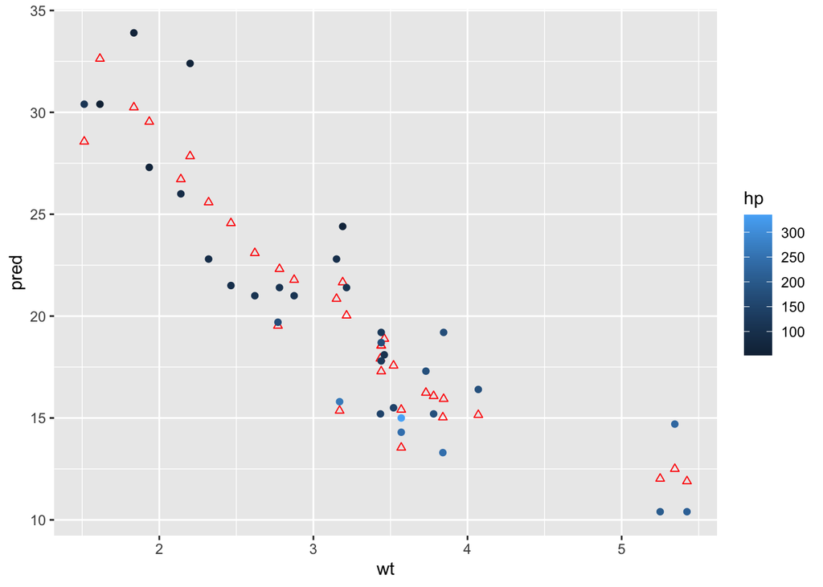

```r
add_predictions(mtcars,mod2) %>%
  ggplot(aes(x=wt)) +
  geom_point(aes(y=pred),color="Red",shape=2) +
  geom_point(aes(y=mpg,color=hp))
```

### So what?

We can see most of the predicted values are relatively close. Well, it at least follows a the negative trend… Was our model perfect? No. Was it horrible? Dr. Zahn might think so. But I think it looks okay.